# Project 2

Analysing the impact of studying online vs on campus on a university student’s academic performance.

480434182, 480385183, 510615460, 480514277, 500377815

University of Sydney | 8 October 2021

# 1 Executive Summary

- This report aims to investigate how studying online affects the academic performance of university students.
- The main discovery was that although students dedicated more time to uni work when studying remotely they preferred the academic experience on campus and received higher grades when attending classes in-person.

# 2 Full Report

## 2.1 Initial Data Analysis (IDA)

```r
# Read in your survey data
library(ggplot2)
survey = read.csv(file = 'cc_vs_re_final.csv')
head(survey)
```

```
##                      Timestamp gender currentyear internationalStudy
## 1 2021/09/16 2:15:08 PM GMT+10   Male       Third                Yes
## 2 2021/09/16 2:15:53 PM GMT+10 Female      Second                 No
## 3 2021/09/16 2:38:20 PM GMT+10   Male       Third                 No
## 4 2021/09/16 2:38:48 PM GMT+10   Male      Second                Yes
## 5 2021/09/16 2:41:33 PM GMT+10   Male     Honours                 No
## 6 2021/09/16 2:42:16 PM GMT+10 Female       Third                 No
##   studiedOnCampus highestAve_cc highestAve_re hoursSpentStudying_cc
## 1             Yes            83            83                    20
## 2             Yes            93            91                    30
## 3             Yes            92            86                    22
## 4             Yes            76            78                    14
## 5             Yes            83            69                    18
## 6             Yes            84            78                    25
##   hoursSpentStudiying_re                    ccVSre perceivedMarkChange
## 1                     15    Strongly prefer online      0 - 20 % lower
## 2                     30               Indifferent     0 - 20 % higher
## 3                     15 Strongly prefer on-campus     0 - 20 % higher
## 4                     20          Prefer on-campus     0 - 20 % higher
## 5                     15          Prefer on-campus       20-40% higher
## 6                     20          Prefer on-campus       20-40% higher
```

```r
tail(survey)
```

```
##                       Timestamp gender currentyear internationalStudy
## 30 2021/09/16 5:58:51 PM GMT+10   Male    Postgrad                 No
## 31 2021/09/16 6:06:57 PM GMT+10 Female      Fourth                 No
## 32 2021/09/16 7:57:31 PM GMT+10 Female       Third                 No
## 33 2021/09/16 8:38:05 PM GMT+10 Female       First                Yes
## 34 2021/09/17 8:41:38 AM GMT+10 Female       Third                 No
## 35 2021/09/17 9:38:01 PM GMT+10 Female       Third                 No
##    studiedOnCampus highestAve_cc highestAve_re hoursSpentStudying_cc
## 30             Yes            77            84                    12
## 31             Yes            93            93                     4
## 32             Yes            75            79                    10
## 33             Yes            75            85                    20
## 34             Yes            82            79                     4
## 35             Yes            89            92                    20
##    hoursSpentStudiying_re                    ccVSre perceivedMarkChange
## 30                     15             Prefer online      0 - 20 % lower
## 31                      4               Indifferent     0 - 20 % higher
## 32                      8          Prefer on-campus     0 - 20 % higher
## 33                     30          Prefer on-campus        20-40% lower
## 34                      6          Prefer on-campus       20-40% higher
## 35                     20 Strongly prefer on-campus     0 - 20 % higher
```

```r
str(survey)
```

```
## 'data.frame':    35 obs. of  11 variables:
##  $ Timestamp             : chr  "2021/09/16 2:15:08 PM GMT+10" "2021/09/16 2:15:53 PM GMT+10" "2021/09/16 2:38:20 PM GMT+10" "2021/09/16 2:38:48 PM GMT+10" ...
##  $ gender                : chr  "Male" "Female" "Male" "Male" ...
##  $ currentyear           : chr  "Third" "Second" "Third" "Second" ...
##  $ internationalStudy    : chr  "Yes" "No" "No" "Yes" ...
##  $ studiedOnCampus       : chr  "Yes" "Yes" "Yes" "Yes" ...
##  $ highestAve_cc         : int  83 93 92 76 83 84 97 86 89 82 ...
##  $ highestAve_re         : int  83 91 86 78 69 78 88 76 82 87 ...
##  $ hoursSpentStudying_cc : int  20 30 22 14 18 25 15 30 30 12 ...
##  $ hoursSpentStudiying_re: int  15 30 15 20 15 20 18 25 25 6 ...
##  $ ccVSre                : chr  "Strongly prefer online" "Indifferent" "Strongly prefer on-campus" "Prefer on-campus" ...
##  $ perceivedMarkChange   : chr  "0 - 20 % lower" "0 - 20 % higher" "0 - 20 % higher" "0 - 20 % higher" ...
```

### 2.1.1 Summary:

#### 2.1.1.2 Structure:

- Each row represents an individual response, with 35 responses recorded in total.
- Each column displays a survey question, with 10 variables in total (6 qualitative and 4 quantitative).

#### 2.1.1.4 Assumptions

- That respondents would answer truthfully in regards to achieved grades.
- That everyone has the same definition of studying.
- That all respondents provided reliable averages for hours studying per week.

#### 2.1.1.5 Data Cleaning

- The responses made by students who didn’t have exposure to on-campus study were removed from the data set.
- Removed one result that was submitted prior to finalizing the survey.
- Changed the type of responses from questions to variables.

## 2.2 Research Question(s)

### 2.2.1 Does online study impact a student’s academic performance?

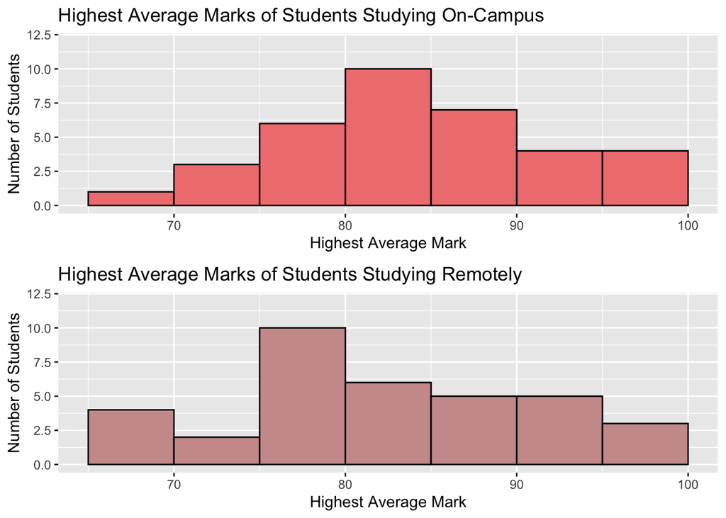

```r
library(gridExtra)
library(ggplot2)

cc = ggplot(survey, aes(highestAve_cc)) + geom_histogram(breaks=seq(65, 100, by=5), col="black", fill="lightcoral") + labs(title="Highest Average Marks of Students Studying On-Campus", x="Highest Average Mark", y="Number of Students") + xlim(c(65,100)) + ylim(c(0,12))

re = ggplot(survey, aes(highestAve_re)) + geom_histogram(breaks=seq(65, 100, by=5), col="black", fill="rosybrown3") + labs(title="Highest Average Marks of Students Studying Remotely", x="Highest Average Mark", y="Number of Students") + xlim(c(65,100)) + ylim(c(0,12))

grid.arrange(cc, re, nrow = 2)
```

```r
mean(survey$highestAve_cc)
```

```
## [1] 84.94286
```

```r
mean(survey$highestAve_re)
```

```
## [1] 83.08571
```

#### 2.2.1.1 Analysis

- The mean average mark achieved by students on-campus was about 1.86% higher than those who studied remotely.
- As expected, students achieved higher marks whilst studying and attending classes on-campus compared to when studying/attending classes online.
- Thus, online study does have an impact on academic achievements as it appears to limit a student’s ability to achieve the higher marks they received whilst studying/attending classes on-campus.

### 2.2.2 Does studying online vs on campus impact the amount of hours studied per week?

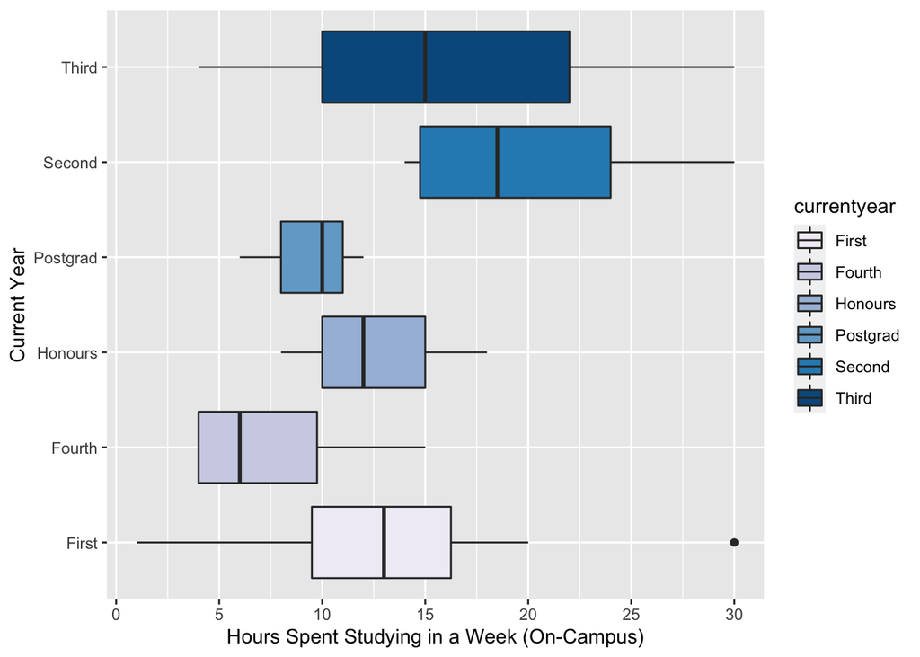

```r
library(ggplot2)

ggplot(survey, aes(y=currentyear, x=hoursSpentStudying_cc, fill=currentyear)) + geom_boxplot() + labs(y= "Current Year", x = "Hours Spent Studying in a Week (On-Campus)") + scale_fill_brewer(palette="PuBu")+ scale_x_continuous(n.breaks = 8)
```

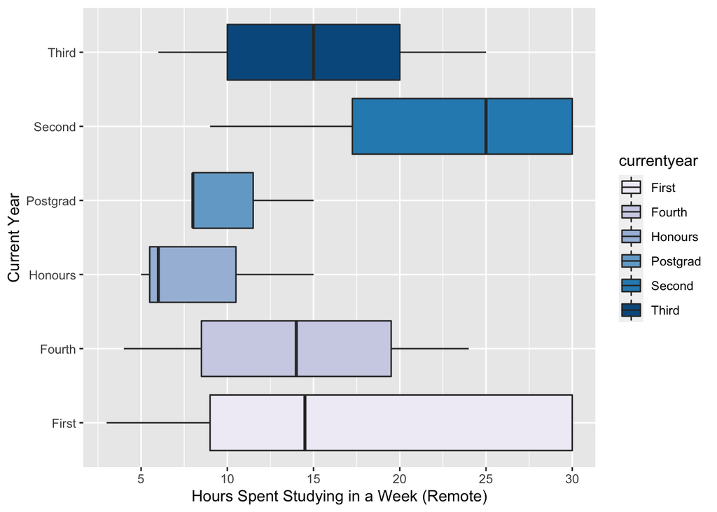

```r
ggplot(survey, aes(y=currentyear, x=hoursSpentStudiying_re, fill=currentyear)) + geom_boxplot() + labs(y= "Current Year", x = "Hours Spent Studying in a Week (Remote)") + scale_fill_brewer(palette="PuBu") + scale_x_continuous(n.breaks = 8)
```

### 2.2.3 Does the number of hours spent studying online vs on campus affect the marks received by students?

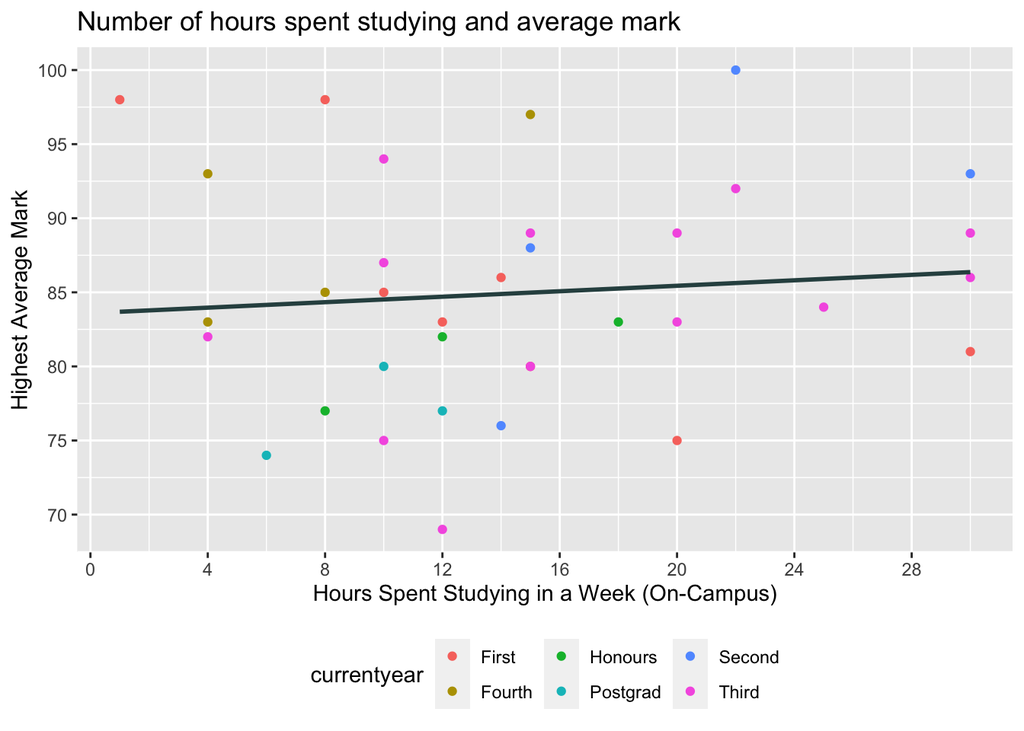

```r
ggplot(survey, aes(y=highestAve_cc, x=hoursSpentStudying_cc)) + geom_point(aes(colour = currentyear)) + labs(y= "Highest Average Mark", x = "Hours Spent Studying in a Week (On-Campus)") + ggtitle("Number of hours spent studying and average mark") + geom_smooth(method = "lm", se=F, color = "darkslategray") + scale_x_continuous(n.breaks = 10) +scale_y_continuous(n.breaks = 10) + theme(legend.position = "bottom")
```

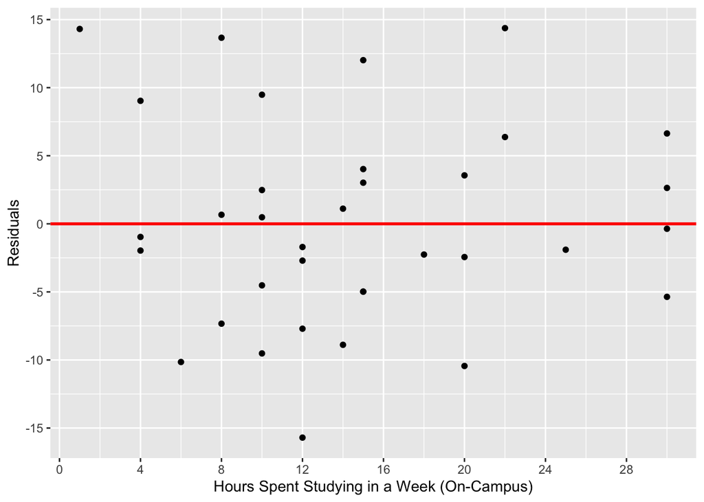

```r
l = lm(survey$highestAve_cc ~ survey$hoursSpentStudying_cc)

ggplot(survey, aes(y=l$residuals, x=hoursSpentStudying_cc)) + geom_point() + geom_hline(yintercept=0, colour = "red", size = 1) + ylab("Residuals") + xlab("Hours Spent Studying in a Week (On-Campus)") + scale_x_continuous(n.breaks = 10) + scale_y_continuous(n.breaks = 10) + theme(legend.position = "top")
```

```r
cor(survey$highestAve_cc, survey$hoursSpentStudying_cc)
```

```
## [1] 0.09660252
```

```r
lm(survey$highestAve_cc ~ survey$hoursSpentStudying_cc)
```

```
##
## Call:
## lm(formula = survey$highestAve_cc ~ survey$hoursSpentStudying_cc)
##
## Coefficients:
##                  (Intercept)  survey$hoursSpentStudying_cc
##                     83.59574                       0.09227
```

```r
model = lm(survey$highestAve_cc ~ survey$hoursSpentStudying_cc)
```

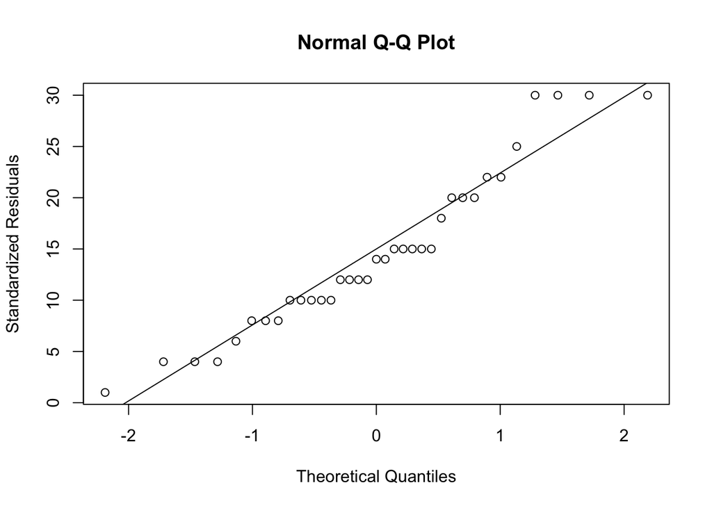

```r
qqnorm(survey$hoursSpentStudying_cc, ylab = "Standardized Residuals")
qqline(survey$hoursSpentStudying_cc)
```

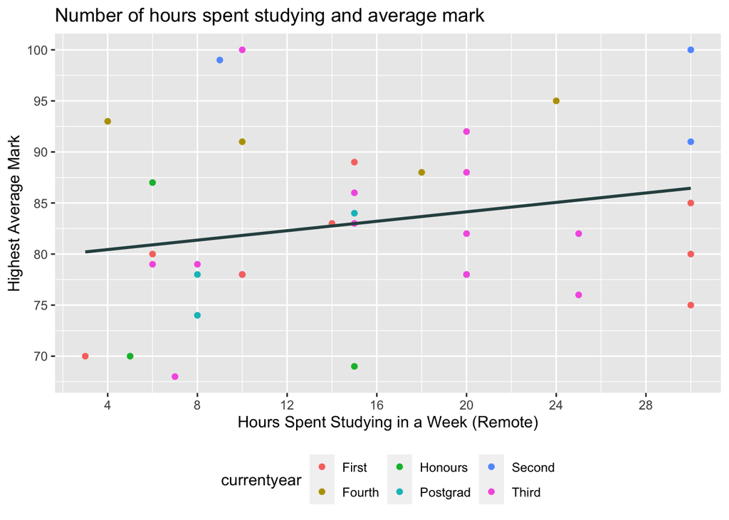

```r
library(ggplot2)

ggplot(survey, aes(y=highestAve_re, x=hoursSpentStudiying_re)) + geom_point(aes(colour = currentyear)) + labs(y= "Highest Average Mark", x = "Hours Spent Studying in a Week (Remote)") + ggtitle("Number of hours spent studying and average mark") + geom_smooth(method = "lm", se=F, color = "darkslategray") + scale_x_continuous(n.breaks = 10) +
scale_y_continuous(n.breaks = 10) +
theme(legend.position = "bottom")
```

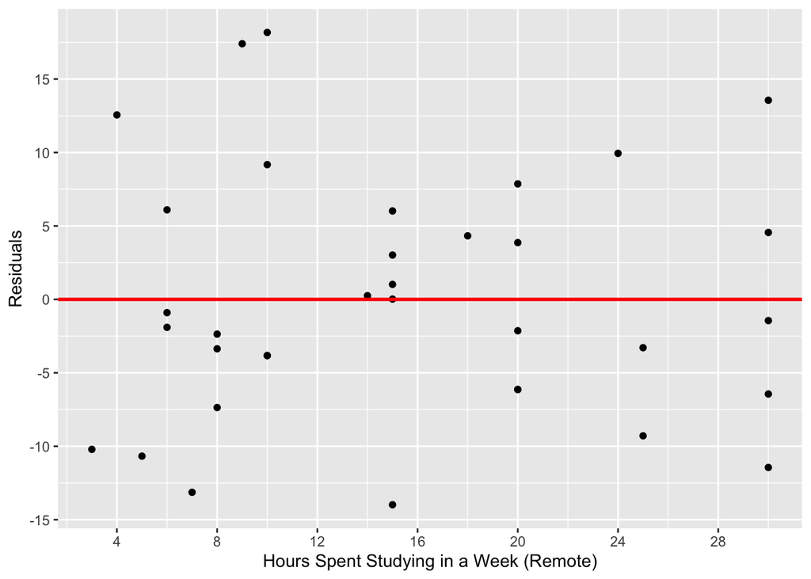

```r
l = lm(survey$highestAve_re ~ survey$hoursSpentStudiying_re)

ggplot(survey, aes(y=l$residuals, x=hoursSpentStudiying_re)) + geom_point() + geom_hline(yintercept=0, colour = "red", size = 1) + ylab("Residuals") + xlab("Hours Spent Studying in a Week (Remote)") + scale_x_continuous(n.breaks = 10) +
scale_y_continuous(n.breaks = 10) +  theme(legend.position = "bottom")
```

```r
cor(survey$highestAve_re, survey$hoursSpentStudiying_re)
```

```
## [1] 0.2288794
```

```r
lm(survey$highestAve_re ~ survey$hoursSpentStudiying_re)
```

```
##
## Call:
## lm(formula = survey$highestAve_re ~ survey$hoursSpentStudiying_re)
##
## Coefficients:
##                   (Intercept)  survey$hoursSpentStudiying_re
##                       79.5167                         0.2309
```

```r
model = lm(survey$highestAve_re ~ survey$hoursSpentStudiying_re)
```

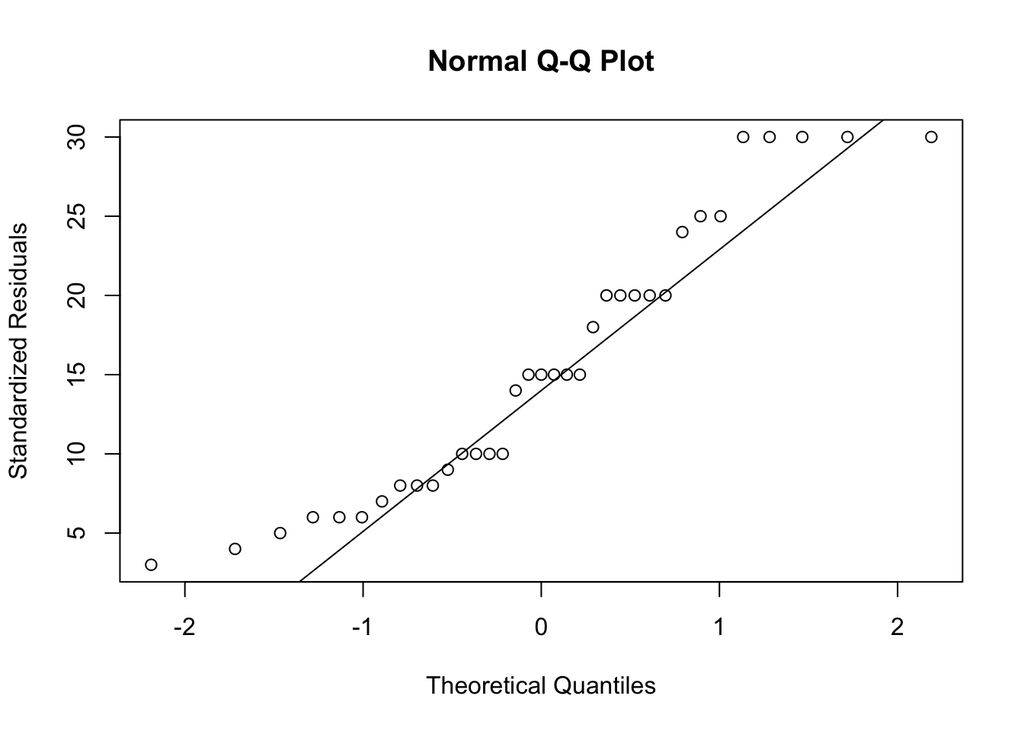

```r
qqnorm(survey$hoursSpentStudiying_re, ylab = "Standardized Residuals")
qqline(survey$hoursSpentStudiying_re)
```

#### 2.2.3.1 Analysis

- There appears to be a weak positive correlation between the number of hours spent studying per-week and academic performance during on-campus semesters.
- However, there is a slightly stronger positive correlation between the number of hours spent studying per week and academic performance during semesters with predominantly online delivery.
- The heteroscedasticity of the residual plots indicates that linear regression may not be an appropriate model.

### 2.2.4 Do students believe that studying on campus would improve their academic performance?

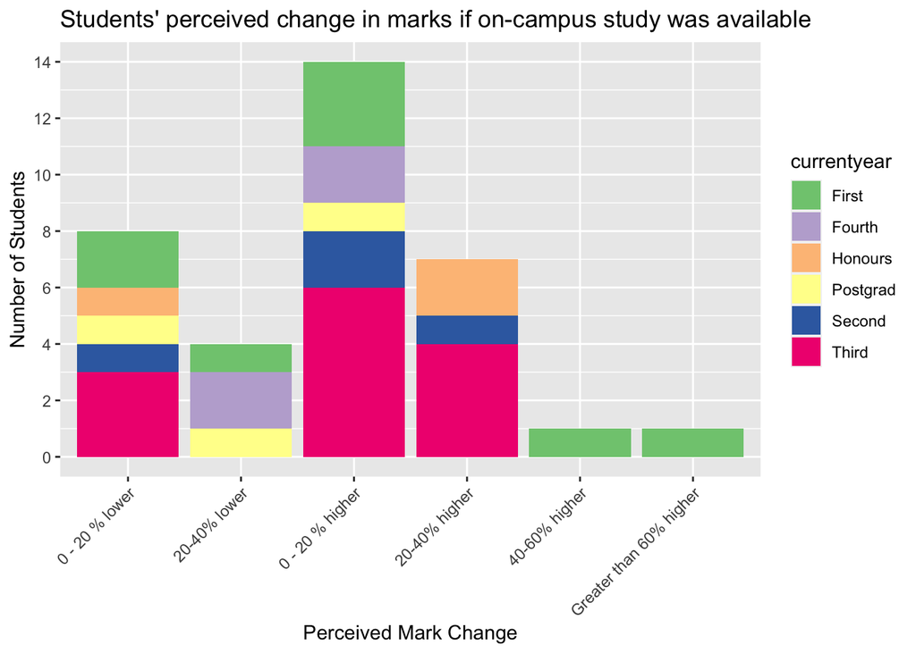

```r
library(ggplot2)

#Add order of current years
order_marks = ordered(survey$perceivedMarkChange,levels = c("0 - 20 % lower", "20-40% lower","0 - 20 % higher", "20-40% higher", "40-60% higher", "Greater than 60% higher"))

ggplot(survey, aes(x=factor(order_marks)), group = interaction(order_marks, currentyear)) + geom_bar(aes(fill=currentyear)) + ylab("Number of Students") + xlab("Perceived Mark Change") + ggtitle("Students' perceived change in marks if on-campus study was available") + scale_fill_brewer(palette="Accent") +
scale_y_continuous(n.breaks = 10) + theme(axis.text.x = element_text(angle=45, hjust=1))
```

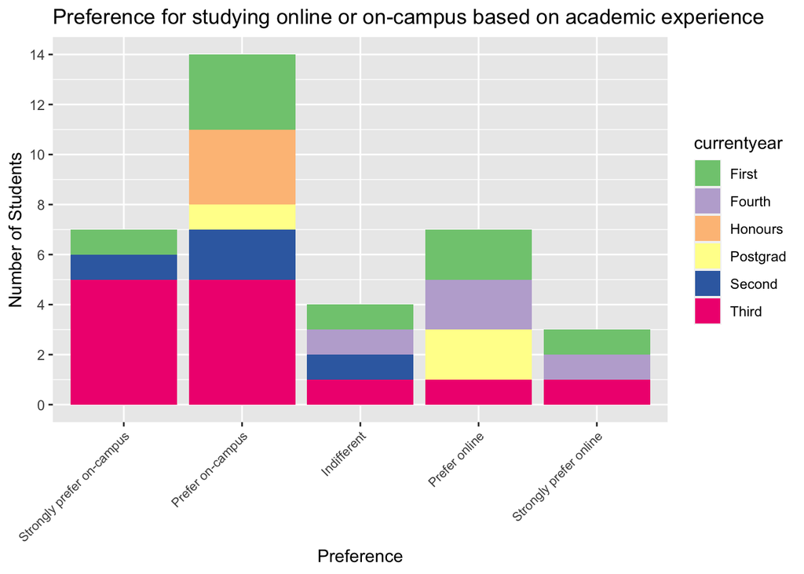

```r
order_preference = ordered(survey$ccVSre,levels = c("Strongly prefer on-campus", "Prefer on-campus","Indifferent", "Prefer online", "Strongly prefer online"))

ggplot(survey, aes(x=factor(order_preference)), group = interaction(order_preference, currentyear))+ geom_bar(aes(fill=currentyear)) + ylab("Number of Students") + xlab("Preference") + ggtitle("Preference for studying online or on-campus based on academic experience") + scale_fill_brewer(palette="Accent") + scale_y_continuous(n.breaks = 10) + theme(axis.text.x = element_text(angle=45, hjust=1, size = 8))
```

#### 2.2.4.1 Analysis

- The majority of students (66%) believe that they would receive higher grades if they could study on-campus instead of studying online during the current semester.
- 60% of the students prefer studying on campus whilst only 11% were indifferent to the idea and 29% preferred online study.
- Thus as anticipated, the majority of students believe that studying on-campus would improve their academic performance and they also prefer the overall academic experience that on-campus study provides.

# 3 Articles

Our findings aligned with research conducted on students conducting study online. Disconnect between student/lecturer, internet issues and poor allotment of lecture time were all factors in dissatisfaction of online study (Khalil, R. et al.(2020)) . This leads to students completing less lectures/work, which directly correlates with lower results (Williams, A., Birch, E., & Hancock, P. (2012))

# 4 References

- Alboukadel. (2019, December 25). The A - Z Of Rcolorbrewer Palette You Must Know. Retrieved from https://www.datanovia.com/en/blog/the-a-z-of-rcolorbrewer-palette/
- Prop.table: Express Table Entries as Fraction of Marginal Table. (n.d.). Retrieved from https://www.rdocumentation.org/packages/base/versions/3.6.2/topics/prop.table
- Khalil, R., Mansour, A.E., Fadda, W.A. et al. The sudden transition to synchronized online learning during the COVID-19 pandemic in Saudi Arabia: a qualitative study exploring medical students’ perspectives. (28 August 2020). Retrieved from https://doi.org/10.1186/s12909-020-02208-z
- Williams, A., Birch, E., & Hancock, P. (2012). The impact of online lecture recordings on student performance. Australasian Journal of Educational Technology, 28(2). https://doi.org/10.14742/ajet.869
- Ggplot2.tidyverse.org. (2021) Bar charts — geom_bar. Retrieved from https://ggplot2.tidyverse.org/reference/geom_bar.html 2021.
- Page, g. (2021). ggplot2 - Easy Way to Mix Multiple Graphs on The Same Page - Articles - STHDA. Retrieved from http://www.sthda.com/english/articles/24-ggpubr-publication-ready-plots/81-ggplot2-easy-way-to-mix-multiple-graphs-on-the-same-page/

# 5 Acknowledgments

[output not shown]